# Your First Day with AI in VS Code

Nothing installed yet? Start here.

Setup Workshop

[figure not shown]

**Open the slides on your computer**shortie.fyi/ai-vscode

## You don’t need to be a programmer

Why and what

An AI helper inside an editor can read your files, write new ones, change what is there, and run tools for you.

Today is setup, not coding.

## Three things we’ll set up

Why and what

1

VS CodeThe editor, where your files and the AI live together.

2

An AI helperCodex, in a sidebar next to your files.

3

A toolboxSmall command-line tools: the helper’s hands.

## Download VS Code

Install and open

1. Go to code.visualstudio.com.
2. Click the big download button. It picks Mac or Windows for you.
3. Wait for the file to finish downloading.

A file named like VSCode-darwin or VSCodeUserSetup is in your Downloads folder.

What is VS Code? →

## Install it

Install and open

Mac

Open the downloaded file, drag **Visual Studio Code** into **Applications**, then open it from there.

Windows

Run the installer. Accept the defaults and leave **Add to PATH** checked.

The VS Code welcome screen opens.

## Four things to know

Install and open

You only need these four parts of the window.

[figure not shown]

Your files and folders, on the left.

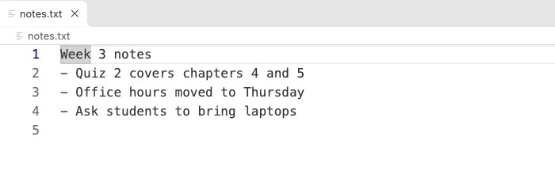

### Editor

The middle: where a file opens.

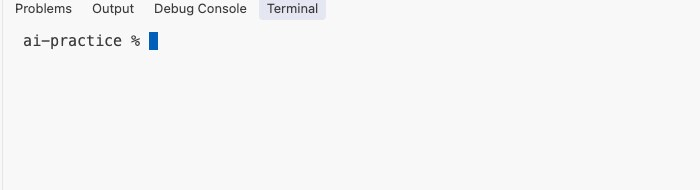

### Terminal

Where commands run. Open it from the Terminal menu.

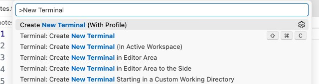

### Command palette

Search every action. Mac `cmd`+`shift`+`P`, Windows `ctrl`+`shift`+`P`.

## Make a project folder

Install and open

1. Create a folder named `ai-practice` in your Documents folder.
2. In VS Code, choose **File → Open Folder** and pick it.
3. When asked, choose **Yes, I trust the authors**.

The name `ai-practice` shows at the top of the sidebar.

## Add the AI helper

Add the AI

1. Click the **Extensions** icon in the left bar (four squares).
2. Search for **Codex** and choose the one from **OpenAI**.
3. Click **Install**.

A Codex icon appears in the left bar.

[figure not shown]

[figure not shown]

What is Codex? →

## Get your BYU-I ChatGPT access

Add the AI

1. Go to byui.edu/ai/tools/chatgpt and select the access link.
2. Choose **Church Educational System**.
3. Enter your BYU-I **username**@byui.edu. Do not use your other email address.

**Not sure of your username?** Sign in to Outlook on the web and click your account icon. The address shown is `username@byui.edu`. Your username is the part before the @.

ChatGPT opens in your browser and you are signed in.

Already have access? Skip ahead. Screens and workspace choices: see the Codex at BYU-I deck.

## Open Codex in VS Code

Add the AI

1. Open the command palette.
2. Select **Codex: Open Codex Side Bar**.
3. Skip the guide and notifications that appear.
4. If it asks you to sign in, sign in with the same account.

The Codex side bar opens. That means VS Code is connected.

Already signed in to the Codex app? VS Code should sign you in automatically.

## A tool is a command the AI can run

Give it a toolbox

The AI can use your computer the way you would from the terminal: by typing commands.

1

You ask“What changed in my files today?”

2

The AI runs a commandIt types `git status` in the terminal. You approve it first.

3

It reads the result and answersIt explains the output in plain words, and can run the next command.

## Without tools, the AI can only talk

Give it a toolbox

| Tool | CLI? | Lets the AI… | What is? |
| --- | --- | --- | --- |
| [Homebrew](https://brew.sh) / [winget](https://learn.microsoft.com/windows/package-manager/winget/) | Yes | install the rest for you | Package manager → |
| [Git](https://git-scm.com) | Yes | show what it changed, and undo it | Git → |
| [uv](https://docs.astral.sh/uv/) | Yes | run Python without setup headaches | uv → |
| [Quarto](https://quarto.org) | Yes | turn text into slides and documents | Quarto → |
| [Playwright](https://playwright.dev) | Yes | open a page and look at it | Playwright → |
| [Node.js](https://nodejs.org) | Yes | run many AI tools | Node.js → |
| [GitHub](https://github.com) | No | store your work online | GitHub → |
| [GitHub CLI](https://cli.github.com) | Yes | work with GitHub from the terminal | GitHub CLI → |

What is a CLI tool?

- A program you run by typing its name in the terminal, like `git status`.
- It does real work: installs software, changes files, builds documents, talks to websites.
- It reports back in text, so the AI can read the result and choose the next step.

## Every command in one place

Give it a toolbox

**Restart VS Code before you run these commands.**

Mac · 1 Package manager

```bash
/bin/bash -c "$(curl -fsSL https://raw.githubusercontent.com/Homebrew/install/HEAD/install.sh)"
```

2 Tools

```bash
brew install git uv node gh
brew install --cask quarto
```

3 Set up

```bash
uv python install
uvx playwright install chromium
gh auth login
```

4 Check

```bash
git --version; uv --version; quarto --version; node --version; gh --version
```

Windows · 1 Tools

```bash
winget install --id Git.Git -e
winget install --id astral-sh.uv -e
winget install --id Posit.Quarto -e
winget install OpenJS.NodeJS.LTS
winget install --id GitHub.cli -e
```

Close and reopen the terminal.

2 Set up

```bash
uv python install
uvx playwright install chromium
gh auth login
```

3 Check

```bash
git --version; uv --version; quarto --version; node --version; gh --version
```

Run each block in order.  
Use the Copy button in the corner of a block.

[figure not shown]

**Copy these on your computer**shortie.fyi/ai-commands

## Install the package manager

Give it a toolbox

What the AI can do

With a package manager, the AI can install the rest of your tools for you.

Open the terminal: **Terminal → New Terminal**. Paste the command for your computer.

Mac · Homebrew

```bash
/bin/bash -c "$(curl -fsSL https://raw.githubusercontent.com/Homebrew/install/HEAD/install.sh)"
```

Follow the prompts. Enter your Mac password when asked.

Windows · winget

```bash
winget --version
```

Windows already includes winget. If a version number prints, you are done.

A version number prints. On Mac, run `brew –version`.

What is a package manager? →

## Git, uv, and Quarto

Give it a toolbox

What the AI can do

With **Git**, the AI can show you what it changed, and undo it.

With **uv**, the AI can run Python for you without any setup headaches.

With **Quarto**, the AI can turn plain text into slides and documents.

Mac

```bash
brew install git uv
brew install --cask quarto
```

Windows

```bash
winget install --id Git.Git -e
winget install --id astral-sh.uv -e
winget install --id Posit.Quarto -e
```

Close and reopen the terminal afterward.

`git –version`, `uv –version`, and `quarto –version` each print a number.

What is Git? →What is uv? →What is Quarto? →

## Install Python

Give it a toolbox

What the AI can do

With **uv**, the AI can run Python for you without any setup headaches.

uv installs Python for you. The command is the same on Mac and Windows. Open a new terminal first.

```bash
uv python install
uv run python --version
```

The AI will run Python through `uv run`, so you never manage Python yourself.

A version like `Python 3.13` prints.

What is uv? →

## Playwright and Node

Give it a toolbox

What the AI can do

With **Playwright**, the AI can open a web page and look at it.

With **Node.js**, the AI can run many other AI tools.

Mac

```bash
uvx playwright install chromium
brew install node
```

Windows

```bash
uvx playwright install chromium
winget install OpenJS.NodeJS.LTS
```

Close and reopen the terminal afterward.

`node –version` prints a number, and the Playwright install finishes without errors.

What is Playwright? →What is Node.js? →

## Create a GitHub account

Give it a toolbox

What the AI can do

With **GitHub**, the AI can store your work online.

1. Go to github.com/signup.
2. Use an email you will keep. Pick a professional username.
3. Verify your email, then turn on two-factor authentication.

The free plan is enough. Nothing you make is public unless you choose that.

You can sign in at github.com and see your empty profile.

What is GitHub? →Trouble signing up? →

## Connect GitHub to your computer

Give it a toolbox

What the AI can do

With the **GitHub CLI**, the AI can work with GitHub from the terminal.

Mac

```bash
brew install gh
gh auth login
```

Windows

```bash
winget install --id GitHub.cli -e
gh auth login
```

Choose **GitHub.com**, **HTTPS**, then **Login with a web browser**.

`gh auth status` says you are logged in.

What is the GitHub CLI? →

## Let the AI check its own toolbox

Give it a toolbox

Your first real task for the AI. It runs the commands. You approve each one.

The AI reports a version for each tool. Anything missing, it offers to install.

## Build something and see it

Use it for real

1. Watch the AI write the file, render it, and open it.
2. Open the screenshot it saved in the sidebar.

You have a `.qmd` file, a rendered `.html` file, and a screenshot.

## Ask for a change

Use it for real

1. Read the change the AI proposes before accepting it.
2. Choose **Accept** or **Reject**.
3. Compare the new screenshot with the first one.

## You stay in charge

Use it for real

> “When intelligence is plentiful, volition is valuable.”

David Brooks, “The People Who Will Thrive in the AI Age,” *The Atlantic*, June 28, 2026.

Git shows every change. Read it, keep it, or undo it: `git restore filename`.

## Where to go next

Use it for real

1. Try the same steps on a real task: a syllabus, a quiz bank, a data file.
2. Save the project to GitHub: ask the AI to run `gh repo create`.

What is the terminal? →Something not working? →Need R? →Using Claude? →

## Backup and appendix slides

After the main deck

The main deck ends at slide 24. What follows is for when you need it. Jump in with a link, or keep paging.

1

Backup · slides 26–29What is the terminal? · Need R? (rig) · When a command is not found · GitHub sign-up trouble

2

Appendix A: Using Claude · slides 30–35Install the extension · Sign in · Terminal install · Same prompts · Codex or Claude?

3

Appendix B: Tool profiles · slides 36–46One page per tool: VS Code · Codex · package manager · Git · uv · Quarto · Playwright · Node.js · GitHub · GitHub CLI · rig

← Back to Where to go next

## What is the terminal?

Backup

A place to give your computer written instructions instead of clicking.

- Open it in VS Code: **Terminal → New Terminal**.
- Type a command, press Enter, read the reply.
- You never have to memorize commands. The AI types them, and you approve.

← Back to Where to go next

## Need R? Install it with rig

Backup · for statistics faculty

Mac

```bash
brew tap r-lib/rig
brew install --cask rig
rig add release
```

Windows

```bash
winget install posit.rig
rig add release
```

`R –version` prints a version. Quarto can now run R code chunks.

What is rig? →

← Back to Where to go next

## When a command is not found

Backup

- **“command not found” or “not recognized”:** close the terminal and open a new one. Installers update your path only for new windows.
- **A download is blocked:** try another network, or ask the AI to explain the error.
- **Codex sign-in loops:** sign out, restart VS Code, sign in again.
- **Stuck anywhere:** paste the whole error into the AI and ask what it means.

← Back to Where to go next

## GitHub sign-up trouble

Backup

- **No verification email:** check spam, then use **Resend** on the GitHub page.
- **Username taken:** add your initials or your department.
- **Lost your two-factor device:** use the recovery codes you saved at sign-up.
- **Browser step stuck in `gh auth login`:** copy the one-time code by hand and open github.com/login/device.
- **BYU-I email or personal?** A personal email lasts; a work email can be added as a second address.

← Back to Create a GitHub account

## Using Claude instead of Codex

Appendix A · Claude

Same workspace, same tools, different helper.

- Claude uses its own account and sign-in.
- Everything else in this deck stays the same: VS Code, the toolbox, the prompts.

Install the extension →← Back to Where to go next

## Install the Claude Code extension

Appendix A · Claude

1. Open **Extensions** in VS Code.
2. Search for **Claude Code** and choose the one from **Anthropic**.
3. Click **Install**.

A Claude icon appears in the editor or the left bar.

## Sign in to Claude

Appendix A · Claude

1. Open the Claude panel.
2. Choose to sign in with your personal Claude subscription (Pro or Max).
3. Approve the sign-in in your browser, then return to VS Code.

The Claude panel shows a chat box.

## Claude in the terminal (optional)

Appendix A · Claude

Mac

```bash
curl -fsSL https://claude.ai/install.sh | bash
claude --version
```

Windows · PowerShell

```bash
irm https://claude.ai/install.ps1 | iex
claude --version
```

`claude –version` prints a number.

## Same prompts, new helper

Appendix A · Claude

Re-run these with Claude and compare.

1. The toolbox check (slide: Let the AI check its own toolbox).
2. The one-slide Quarto deck with a Playwright screenshot (slide: Build something and see it).

## Codex or Claude?

Appendix A · Claude

|  | Codex | Claude |
| --- | --- | --- |
| Account | BYU-I ChatGPT access | Personal Claude subscription |
| Runs in | VS Code sidebar | VS Code panel and terminal |
| Approvals | Asks before running commands | Asks before running commands |

← Back to Where to go next

## VS Code: the editor where everything happens

Appendix B · Tool profile

What it is

A free editor for text and code files. Your files, the terminal, and the AI helper all sit in one window.

What the AI uses it for

It reads the files in your open folder and proposes changes you can accept or reject.

Try it

Open a folder, then open the command palette.

[figure not shown]

code.visualstudio.com · screenshot, October 2026. Logos and screenshots belong to their owners.

code.visualstudio.com← Back to Download VS Code

## Codex: the AI helper in your sidebar

Appendix B · Tool profile

What it is

OpenAI’s coding assistant, added to VS Code as an extension. You chat with it next to your files.

What the AI uses it for

“Summarize this file.” “Add a title slide.” “Run this command and tell me what happened.”

Try it

Ask it: *What files are in this folder?*

[figure not shown]

marketplace.visualstudio.com · screenshot, October 2026. Logos and screenshots belong to their owners.

[Marketplace page](https://marketplace.visualstudio.com/items?itemName=OpenAI.chatgpt)← Back to Add the AI helper

## A package manager: an app store for the terminal

Appendix B · Tool profile

What it is

Homebrew (Mac) and winget (Windows) install and update software from the terminal, with one line each.

What the AI uses it for

“Install Quarto for me.” It runs the install, so you never hunt for download pages.

Try it

Mac: `brew list` · Windows: `winget list`

[figure not shown]

brew.sh · screenshot, October 2026. Logos and screenshots belong to their owners.

brew.sh[winget docs](https://learn.microsoft.com/windows/package-manager/winget/)← Back to Install the package manager

## Git: the undo button for your files

Appendix B · Tool profile

What it is

A tool that remembers every version of your files, so you can see what changed and go back.

What the AI uses it for

“Show me what changed since yesterday.” “Undo that last edit.”

Try it

`git status` lists files that changed.

[figure not shown]

git-scm.com · screenshot, October 2026. Logos and screenshots belong to their owners.

git-scm.com← Back to Git, uv, and Quarto

## uv: Python without the setup headaches

Appendix B · Tool profile

What it is

A fast tool that installs Python and runs Python programs, so you never install Python by hand.

What the AI uses it for

“Run this script.” “Install the chart library and make a plot.”

Try it

`uv python install` installs Python. `uv run python –version` prints its version.

[figure not shown]

docs.astral.sh/uv · screenshot, October 2026. Logos and screenshots belong to their owners.

[docs.astral.sh/uv](https://docs.astral.sh/uv/)← Back to Git, uv, and Quarto

## Quarto: text in, slides and documents out

Appendix B · Tool profile

What it is

Turns a plain text file into slides, documents, PDFs, or websites. It can also run code inside the file.

What the AI uses it for

“Make a slide deck from my notes.” “Render it and show me.”

Try it

`quarto render file.qmd` builds the output.

[figure not shown]

quarto.org · screenshot, October 2026. Logos and screenshots belong to their owners.

quarto.org← Back to Git, uv, and Quarto

## Playwright: lets the AI see a web page

Appendix B · Tool profile

What it is

A tool that controls a web browser from code. It can open pages, click, and take screenshots.

What the AI uses it for

“Open the slide I just made and screenshot it” so it can check its own work.

Try it

Ask the AI to screenshot any web page.

[figure not shown]

playwright.dev · screenshot, October 2026. Logos and screenshots belong to their owners.

playwright.dev← Back to Playwright and Node

## Node.js: the engine behind many AI tools

Appendix B · Tool profile

What it is

A program that runs JavaScript outside the browser. Many AI tools and web tools are built on it.

What the AI uses it for

Running AI tool servers and web-building tools it may reach for later.

Try it

`node –version` prints a number.

[figure not shown]

nodejs.org · screenshot, October 2026. Logos and screenshots belong to their owners.

nodejs.org← Back to Playwright and Node

## GitHub: where your work can live online

Appendix B · Tool profile

What it is

A free website that stores projects tracked with Git. You choose whether each project is private or public.

What the AI uses it for

Saving your project online, sharing it, and publishing slides as a web page.

Try it

Sign in at github.com and look at your profile.

[figure not shown]

github.com · screenshot, October 2026. Logos and screenshots belong to their owners.

github.com← Back to Create a GitHub account

## GitHub CLI: GitHub from the terminal

Appendix B · Tool profile

What it is

The `gh` command signs you in to GitHub once, then lets tools use your account without passwords.

What the AI uses it for

“Create a repository for this project.” “Publish these slides.”

Try it

`gh auth status` shows who is logged in.

[figure not shown]

cli.github.com · screenshot, October 2026. Logos and screenshots belong to their owners.

cli.github.com← Back to Connect GitHub

## rig: R installs without the hassle

Appendix B · Tool profile

What it is

R Installation Manager. It installs R and switches between versions, much as uv does for Python.

What the AI uses it for

“Install the current R.” “Switch to the version this project needs.”

Try it

`rig list` shows installed R versions.

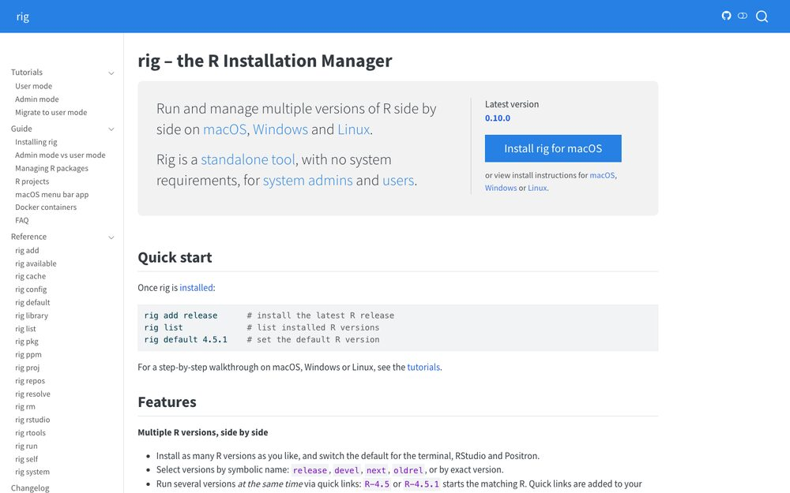

rig.r-lib.org · screenshot, October 2026. Logos and screenshots belong to their owners.

github.com/r-lib/rig← Back to Need R?